# **Analyzing Student Success Factors**

## Summer 2025 Data Science Project

## Zoya Rahman, Abdul Rahem Ariff, Mario Alvarenga, Joshua Egwim

## Contributions

- **Zoya Rahman:** Developed the **Project Idea**, was in charge of making & coordinating all tasks for Github and Colab. For **Dataset Curation & Preprocessing**, curated the Success Rate Dependent Variable, and participated in dataset cleaning. For **Data Exploration & Summary Stats**, dealt with MAR variables through running statistical tests, and plotting a heatmap. Also implemented Logistic Regression model to confirm MAR data, coded the imputation fix, and plotted a correlation matrix for all variables. Implemented a preliminary linear regression model using OLS and interpreted results. For **Machine Learning Algorithm Design & Development**, contributed during code review & problem solving. For **Visualization Result & Analysis Conclusion**, contributed in conclusion & interpretation. For **Report Creation**, converted the colab .ipynb file to .html for website, parsed css and html, edited website for accessibility, and managed github for deployment.
- **Abdul Rahem Ariff:** Filtered and selected ideal Dataset for project. For **Data Exploration & Summary Stats**, theorized and dealt with categorial variable influence using ANOVA testing. Also implemented a preliminary Linear Regression Model for factors of Success Rate. For **Machine Learning Algorithm Design & Development**, determined which models to utilize in design. For **Machine Learning Training & Data Analysis**, developed code for interpreting accuracy on all models, and worked on debugging accuracy results. Also implemented code for metrics to evaluate best model. Additionally contributed in model visualization and implementation for Linear Regression. For **Visualization Result & Analysis Conclusion**, worked heavily on data visualization throughout project such as cleaning final plots, and contributed in conclusion & interpretations for each model. For **Report Creation**, aided Zoya in information transfer & cleaning converted html from ipynb.
- **Mario Alvarenga:** For **Dataset Curation & Preprocessing**, contributed in data cleaning, theorized binning, imputation and encoding methods for categorical variables. For **Data Exploration & Summary Stats**, theorized and dealt with categorial variable influence using ANOVA testing. For **Machine Learning Algorithm Design & Development**, determined how to test our data and all necessary libraries for imports. For **Machine Learning Training & Data Analysis**, implemented data training & splitting data via normalization, along with debugging accuracy results. For **Visualization Result & Analysis Conclusion**, participated in all code review & debugging of visualization. For **Report Creation**, aided in proof reading text for grammatical and logical errors.
- **Joshua Egwim:** For **Data Exploration & Summary Stats**, created box plots for participation quartiles when dealing with MAR data, and developed pairplots and box plots for the dependent variables against Success Rate. For **Machine Learning Algorithm Design & Development**, tracked documentation of entire process. For **Machine Learning Training & Data Analysis**, imported libraries & necessary models, and heavily contributed to debugging accuracy results. Additionally was in charge of Data Visualization for all models, specifically Linear Regression plots. For **Visualization Result & Analysis Conclusion**, worked heavily on data visualization throughout project. For **Report Creation**, aided in proof reading text for grammatical and logical errors.

*Note: Our project was completed exclusively during in person sessions. The following contributions list what each member physically intiated and completed on their own laptops, however, every group member had equal involvement and participation in discussion for all aspects of the project, regardless if explicitly stated for any bolded section.*

# **Introduction**

Our project aims to determine and analyze what makes a Student Successful through the application of Machine Learning Models. Students nowdays have so many different facets of life to balance, and we wanted to develop a model that could intake various features relevant to a student's performance, and determine whether or not a student will be considered successful from that data. Our work is important for the encouragment of students towards specific habits and goals that they should keep focus on to remain successful during their educational career! This tutorial allows for an easily accessible workflow from data cleaning to final interpretation, using a real life dataset from a professor and his roster of students!

# **Data Curation & Preprocessing**

### Dataset:

https://www.kaggle.com/datasets/mahmoudelhemaly/students-grading-dataset

Our dataset is sourced off of Kaggle from a Professor, containing 5,000 records of real student data. It was specifically designed to explore patterns, correlations, and insights regarding academic performance, which makes it perfect for our tutorial! It features 20+ columns, with noteable ones including Total_Score, Extracurricular_Activities, Parent_Education_Level, and even Stress_Level.

Before anything else, first we must begin with importing some libraries so that we can effectively process our data! This project is done using Google Colab and the Python Language. One of our most important libraries for data processing is Pandas, which we will import below along with some mathematical/statistical libraries (numpy, scipy.stats, statsmodels, sklearn) and data visualization libraries (matplotlib & seaborn)!

**Show/Hide Code ▾**

```python
import pandas as pd
import numpy as np

import matplotlib.pyplot as plt
import seaborn as sns

from scipy.stats import ttest_ind, chi2_contingency

from sklearn.preprocessing import StandardScaler
from sklearn.preprocessing import MinMaxScaler

import statsmodels.api as sm
import statsmodels.formula.api as smf
from statsmodels.formula.api import ols
from statsmodels.stats.outliers_influence import variance_inflation_factor
from sklearn.ensemble import RandomForestRegressor
from sklearn.tree import DecisionTreeRegressor
from sklearn.svm import SVR
from sklearn.model_selection import train_test_split, cross_val_score, StratifiedKFold, KFold
from sklearn.metrics import mean_squared_error, r2_score
from sklearn.linear_model import LinearRegression
```

Once we finish our imports, it is time to begin organizing our data so that it is ready for analysis. The most effective way to do this is loading our csv file into a Pandas dataframe, and inspecting the columns! Pandas is an incredibly useful library for data manipulation and analysis, due to its high performance, and user-friendly data structures & data analysis tools.

[Learn more about Pandas here!](https://pandas.pydata.org/docs/getting_started/index.html)

**Show/Hide Code ▾**

```python
df = pd.read_csv("Students Performance Dataset.csv")
df.columns
```

```
Index(['Student_ID', 'First_Name', 'Last_Name', 'Email', 'Gender', 'Age',
       'Department', 'Attendance (%)', 'Midterm_Score', 'Final_Score',
       'Assignments_Avg', 'Quizzes_Avg', 'Participation_Score',
       'Projects_Score', 'Total_Score', 'Grade', 'Study_Hours_per_Week',
       'Extracurricular_Activities', 'Internet_Access_at_Home',
       'Parent_Education_Level', 'Family_Income_Level', 'Stress_Level (1-10)',
       'Sleep_Hours_per_Night'],
      dtype='object')
```

## **Data Cleaning**

Now that we have an idea of our features, we should first begin with checking for major issues in our data. Even though our dataset is partially cleaned, it is best that we make sure to check for basic problems such as missing values across all columns and duplicate values for individuals data points. We also want to change the column names to exclude symbols and spaces, incase it disrupts any future processing.

**Show/Hide Code ▾**

```python
df = df.rename(columns={'Attendance (%)':'Attendance_Pct'})
df = df.rename(columns={'Stress_Level (1-10)':'Stress_Level'})

missing_data = { col: int(df[col].isnull().sum()) for col in df.columns}
print(missing_data)

duplicate = df['Student_ID'].duplicated().sum()
print(duplicate)
```

[output not shown]

We can see that our data has no duplicate students, and that for the most part, we have almost no missing values. Unfortunately, we have 1025 missing data points for Parent Education Level, which is roughly 20% of the entire feature.  
For now, we will take note of this to revisit in our exploratory analysis of what type of missing data this could be, and whether it is significant to impute on. In the meantime, we want to consider other data processing tasks.  
We have many columns that are irrelevant to our analysis, such as identification features. Since we have verified no duplicates, we can choose to use a traditional index, and remove indentifying features from our dataset.

**Show/Hide Code ▾**

```python
df.drop(columns='Student_ID', inplace=True)
df.drop(columns='First_Name', inplace=True)
df.drop(columns='Last_Name', inplace=True)
df.drop(columns='Email', inplace=True)
df
```

|  | Gender | Age | Department | Attendance_Pct | Midterm_Score | Final_Score | Assignments_Avg | Quizzes_Avg | Participation_Score | Projects_Score | Total_Score | Grade | Study_Hours_per_Week | Extracurricular_Activities | Internet_Access_at_Home | Parent_Education_Level | Family_Income_Level | Stress_Level | Sleep_Hours_per_Night |
| --- | --- | --- | --- | --- | --- | --- | --- | --- | --- | --- | --- | --- | --- | --- | --- | --- | --- | --- | --- |
| 0 | Female | 22 | Mathematics | 97.36 | 40.61 | 59.61 | 73.69 | 53.17 | 73.4 | 62.84 | 59.8865 | F | 10.3 | Yes | No | Master's | Medium | 1 | 5.9 |
| 1 | Male | 18 | Business | 97.71 | 57.27 | 74.00 | 74.23 | 98.23 | 88.0 | 98.23 | 81.9170 | B | 27.1 | No | No | High School | Low | 4 | 4.3 |
| 2 | Male | 24 | Engineering | 99.52 | 41.84 | 63.85 | 85.85 | 50.00 | 4.7 | 91.22 | 67.7170 | D | 12.4 | Yes | No | High School | Low | 9 | 6.1 |
| 3 | Female | 24 | Engineering | 90.38 | 45.65 | 44.44 | 68.10 | 66.27 | 4.2 | 55.48 | 51.6535 | F | 25.5 | No | Yes | High School | Low | 8 | 4.9 |
| 4 | Female | 23 | CS | 59.41 | 53.13 | 61.77 | 67.66 | 83.98 | 64.3 | 87.43 | 71.4030 | C | 13.3 | Yes | No | Master's | Medium | 6 | 4.5 |
| ... | ... | ... | ... | ... | ... | ... | ... | ... | ... | ... | ... | ... | ... | ... | ... | ... | ... | ... | ... |
| 4995 | Male | 19 | CS | 96.09 | 45.86 | 45.63 | 74.13 | 81.53 | 9.8 | 51.66 | 53.5470 | F | 7.8 | No | No | Master's | Medium | 10 | 4.5 |
| 4996 | Male | 19 | Mathematics | 96.30 | 78.67 | 47.42 | 57.89 | 85.96 | 47.8 | 52.33 | 59.0240 | F | 24.2 | No | Yes | NaN | Medium | 4 | 7.2 |
| 4997 | Female | 24 | CS | 89.94 | 50.84 | 65.83 | 84.69 | 82.27 | 7.5 | 97.89 | 74.7560 | C | 7.6 | No | Yes | NaN | High | 5 | 6.6 |
| 4998 | Male | 23 | Engineering | 99.09 | 55.44 | 57.45 | 78.78 | 55.96 | 62.9 | 84.74 | 68.6585 | D | 14.5 | Yes | No | PhD | Medium | 10 | 5.9 |
| 4999 | Female | 21 | Mathematics | 90.33 | 93.29 | 88.42 | 87.06 | 65.22 | 64.0 | 66.23 | 78.7485 | C | 29.9 | Yes | Yes | PhD | High | 2 | 5.3 |

5000 rows × 19 columns

Now we need to determine how we will actually measure student performance. After discussion, **we believe that student success should be calculated based on three main features: Total_Score, Stress_Level, and Sleep_Hours_per_Night.** All three of these metrics encompass a students performance academically, mentally, and healthwise. We will combine these three features into a Success_Score that rewards high grades, low stress, and healthy sleep, and then perform our analysis against this metric, to determine what factors contribute to success, and eventually build a model that can predict such!

**Show/Hide Code ▾**

```python
cols = ['Total_Score', 'Stress_Level', 'Sleep_Hours_per_Night']

scaler = StandardScaler()
df[['grade_z','stress_z','sleep_z']] = scaler.fit_transform(df[cols])

df['Success_Score'] = df['grade_z'] + df['sleep_z'] - df['stress_z']

cols = {'grade_z', 'stress_z', 'sleep_z'}
df.drop(columns=cols, inplace=True)
df['Success_Score'].describe()
```

|  | Success_Score |
| --- | --- |
| count | 5.000000e+03 |
| mean | 3.126388e-17 |
| std | 1.725670e+00 |
| min | -5.454023e+00 |
| 25% | -1.181795e+00 |
| 50% | -1.532408e-02 |
| 75% | 1.170110e+00 |
| max | 5.733307e+00 |

**dtype:** float64

# **Exploratory Data Analysis**

Since we have successfully completed our data curation, it's time for us to begin exploring our data and understanding connections, so that we can draw conclusions for our hypothesis.

We want to split our analysis into two distinct phases of testing: **descriptive testing and modeling testing.**  
But first, we should address our missing values from before!

## **Analyzing Missing Values**

There is roughly 20% missing data for Parent_Education_Level. To quickly assess whether our data is MCAR (Missing Completely at Random) or MAR (Missing at Random), we can conduct a **T test for numerical data and Chi-Squared Tests for categorical data.** Both of these tests will produce a p value that quantifies how likely either is. If p value is > 0.05 then MCAR is plausible, but if it is below, it is statistically significant enough to consider MAR.  
We can also use a **heatmap** to visualize if any of our t tests have especially low p values.

[Learn more about missing values here!](https://www.geeksforgeeks.org/machine-learning/ml-handling-missing-values/)

**Show/Hide Code ▾**

```
Age                       t-test p = 0.782
Attendance_Pct            t-test p = 0.467
Midterm_Score             t-test p = 0.964
Final_Score               t-test p = 0.828
Assignments_Avg           t-test p = 0.658
Quizzes_Avg               t-test p = 0.465
Participation_Score       t-test p = 0.008
Projects_Score            t-test p = 0.617
Total_Score               t-test p = 0.731
Study_Hours_per_Week      t-test p = 0.349
Stress_Level              t-test p = 0.912
Sleep_Hours_per_Night     t-test p = 0.762
Gender                    chi2 p = 0.970
Department                chi2 p = 0.492
Extracurricular_Activities chi2 p = 0.383
Internet_Access_at_Home   chi2 p = 0.236
```

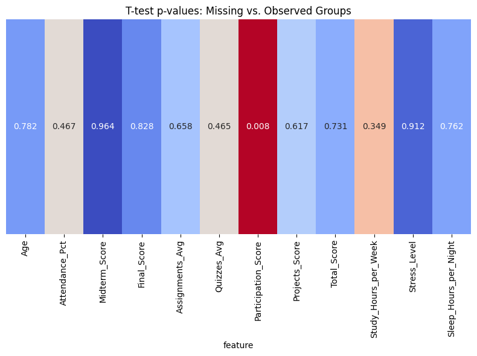

```python
df['miss_PE'] = df['Parent_Education_Level'].isna().astype(int)

numeric_cols = [
    'Age', 'Attendance_Pct', 'Midterm_Score', 'Final_Score',
    'Assignments_Avg', 'Quizzes_Avg', 'Participation_Score',
    'Projects_Score', 'Total_Score', 'Study_Hours_per_Week',
    'Stress_Level', 'Sleep_Hours_per_Night'
]
for col in numeric_cols:
    grp_obs = df.loc[df['miss_PE']==0, col].dropna()
    grp_miss = df.loc[df['miss_PE']==1, col].dropna()
    t_stat, p_val = ttest_ind(grp_obs, grp_miss, equal_var=False)
    print(f"{col:25} t-test p = {p_val:.3f}")


cat_cols = ['Gender', 'Department', 'Extracurricular_Activities', 'Internet_Access_at_Home']
for col in cat_cols:
    ct = pd.crosstab(df[col], df['miss_PE'])
    chi2, p_val, _, _ = chi2_contingency(ct)
    print(f"{col:25} chi2 p = {p_val:.3f}")

p_values = []
for col in numeric_cols:
    grp_obs = df.loc[df['miss_PE']==0, col].dropna()
    grp_miss = df.loc[df['miss_PE']==1, col].dropna()
    p = ttest_ind(grp_obs, grp_miss, equal_var=False).pvalue
    p_values.append(p)

#heatmap
pv_df = pd.DataFrame({'feature': numeric_cols, 'p_value': p_values})
pv_mat = pv_df.set_index('feature').T

plt.figure(figsize=(8,6))
sns.heatmap(
    pv_mat,
    annot=True,
    fmt='.3f',
    cmap='coolwarm_r',
    cbar=False
)
plt.title('T-test p-values: Missing vs. Observed Groups')
plt.yticks([])
plt.tight_layout()
plt.show()
```

Since our T test showed p = 0.008 for Participation_Score, we can not assume MCAR definitively. We should now run a formal MAR check using logistic regression to confirm this. **Logistic regression will tell us if any of our other features can predict whether or not the parent education information is missing.** If this is the case, then we must definitely rule out MCAR and conclude that Parent Education Level is MAR (Missing at Random).  
Note that we are doing a univariate logistic regression test as Participation_Score is the only feature to have been remotely close to the threshold.

[Learn more about Logistic Regression for Machine Learning here!](https://www.geeksforgeeks.org/machine-learning/understanding-logistic-regression/)

**Show/Hide Code ▾**

```python
model = smf.logit(
    'miss_PE ~ Participation_Score',
    data=df
).fit(disp=False)
print(model.summary())
```

```
                           Logit Regression Results
==============================================================================
Dep. Variable:                miss_PE   No. Observations:                 5000
Model:                          Logit   Df Residuals:                     4998
Method:                           MLE   Df Model:                            1
Date:                Sun, 06 Jul 2025   Pseudo R-squ.:                0.001311
Time:                        02:38:07   Log-Likelihood:                -2533.0
converged:                       True   LL-Null:                       -2536.3
Covariance Type:            nonrobust   LLR p-value:                  0.009909
=======================================================================================
                          coef    std err          z      P>|z|      [0.025      0.975]
---------------------------------------------------------------------------------------
Intercept              -1.2018      0.068    -17.588      0.000      -1.336      -1.068
Participation_Score    -0.0031      0.001     -2.576      0.010      -0.005      -0.001
=======================================================================================
```

**Show/Hide Code ▾**

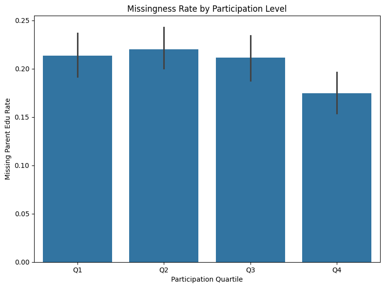

```python
df['Part_bin'] = pd.qcut(df['Participation_Score'], 4, labels=['Q1','Q2','Q3','Q4'])

plt.figure(figsize=(8,6))
sns.barplot(
    x='Part_bin',
    y='miss_PE',
    data=df,
    estimator=lambda x: np.mean(x),  # plots mean(miss_PE) = missing rate
)
plt.ylabel('Missing Parent Edu Rate')
plt.xlabel('Participation Quartile')
plt.title('Missingness Rate by Participation Level')
plt.tight_layout()
plt.show()
```

To fix this issue of MAR, we can consider imputation on Parent_Education_Level with respect to Participation_Score. Because we have not yet conducted Descriptive Testing to see how significant Parent_Education_Level is on our analysis, and because we only have one observed feature affecting our missing values, we will use Single Imputation for now. If we find that Parent_Education_Level is highly relevant to student success, we will revisit and consider Multiple Imputation. We can confirm successful imputation if we return a sum of 0 missing values, and move forward to descriptive testing!

Single Imputation is the method of finding the mode of a certain column and using that to fill in missing values. In this case, we will bin our data points into High and Low Participation_Scores, find the mode for each bins, and use those to impute on our missing values for Parent_Education_Level.

**Show/Hide Code ▾**

```python
df['Part_High'] = df['Participation_Score'] >= df['Participation_Score'].median()

modes = df.groupby('Part_High')['Parent_Education_Level'] \
          .agg(lambda s: s.mode().iat[0])

df['Parent_Education_Level'] = (df['Parent_Education_Level'].fillna(df['Part_High'].map(modes)))

df.drop(columns='Part_High', inplace=True)
df.drop(columns='miss_PE', inplace=True)
df['Parent_Education_Level'].isna().sum()  # should be 0
```

```
np.int64(0)
```

# **Descriptive Testing & Visualization**

Now that our missing values have successfully been imputed on, it is time to begin Descriptive Testing! Descriptive testing is when we want to start exploring some of our features and their correlation to each other, so that we can decide which features are most related to analyzing student success. To do this, we will start by making a correlation matrix!

A correlation matrix is a compact way of visualizing every pairwise linear relationship among a set of numeric variables in a table. Its incredibly useful for EDA (Exploratory Data Analysis) because it allows for quick visualization of predictors that move together. It is also very useful for other applications such as Principal Component Analysis (PCA)!

**Show/Hide Code ▾**

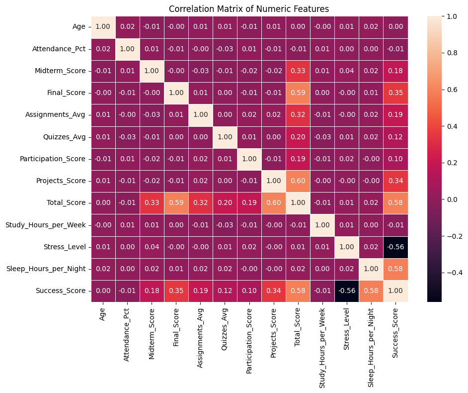

```python
numeric_df = df.select_dtypes(include=[np.number])

corr = numeric_df.corr()
plt.figure(figsize=(10,8))
sns.heatmap(
    corr,
    annot=True,
    fmt=".2f",
    linewidths=0.5,
)
plt.title("Correlation Matrix of Numeric Features")
plt.tight_layout()
plt.show()
```

**Show/Hide Code ▾**

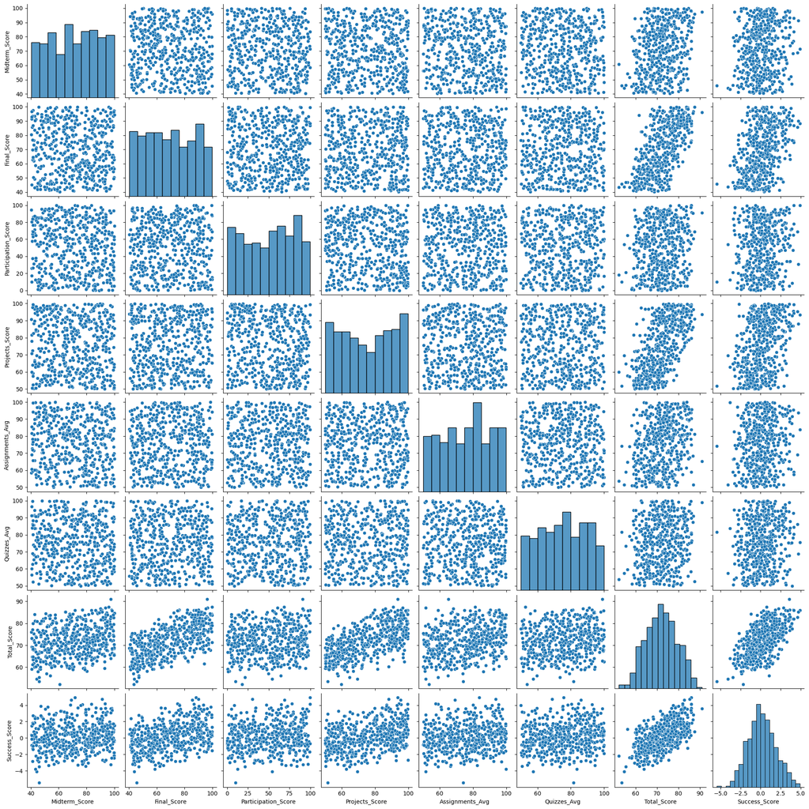

```python
cols = [
    'Midterm_Score',
    'Final_Score',
    'Participation_Score',
    'Projects_Score',
    'Assignments_Avg',
    'Quizzes_Avg',
    'Total_Score', 'Success_Score'
]
subset = df[cols].sample(500, random_state=42)

sns.pairplot(subset, kind='scatter', diag_kind='hist')
```

From the scatter plot, we can conclude visually that **our highly correlated features all cluster in a semi-linear pattern against Success_Score**.  
Since we can conclude that the correlation follows a typical linear pattern, we can continue forward in our exploration with analyzing categorical features!  
The easiest way to analyze our categorical features against a numerical feature is to use an ANOVA test!

An ANOVA test analyzes the variability between and withing groups, to see if those differences are statistically significant. This is done with using group means! Here we are doing a "multi-way" test, where we analyze the unique effect of each of our features, while accounting for the others!

**Show/Hide Code ▾**

```
                                     sum_sq      df         F    PR(>F)
C(Gender)                          3.993112     1.0  1.342015  0.246734
C(Department)                     15.812978     3.0  1.771489  0.150315
C(Extracurricular_Activities)      0.012197     1.0  0.004099  0.948952
C(Internet_Access_at_Home)         0.623921     1.0  0.209689  0.647031
C(Parent_Education_Level)         18.402343     3.0  2.061569  0.103106
C(Family_Income_Level)             6.308562     2.0  1.060099  0.346500
Residual                       14841.591773  4988.0       NaN       NaN
```

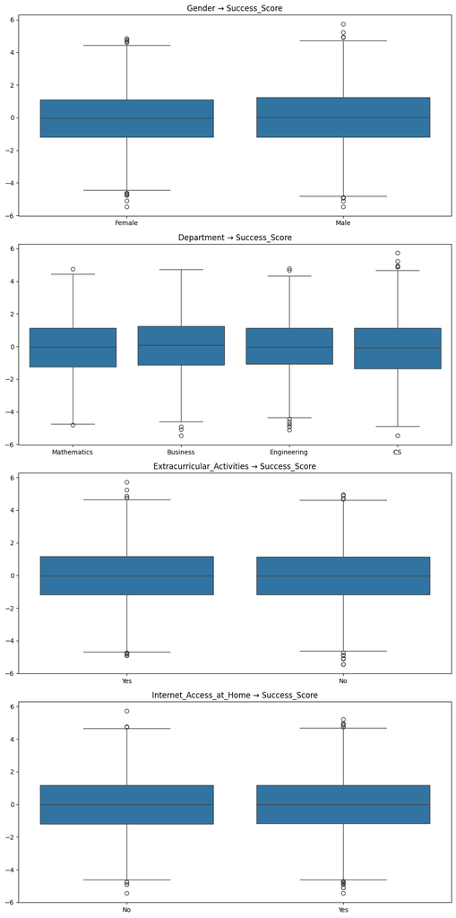

```python
dv   = 'Success_Score'
cats = ['Gender','Department','Extracurricular_Activities','Internet_Access_at_Home','Parent_Education_Level', 'Family_Income_Level']

formula = dv + ' ~ ' + ' + '.join(f'C({c})' for c in cats)

model       = ols(formula, data=df).fit()
anova_table = sm.stats.anova_lm(model, typ=2)   # Type II SS
print(anova_table)

fig, axes = plt.subplots(len(cat_cols), 1, figsize=(10, 20))

for ax, col in zip(axes, cat_cols):
    sns.boxplot(x=col, y=dv, data=df, ax=ax)
    ax.set_title(f'{col} → {dv}')
    ax.set_xlabel('')
    ax.set_ylabel('')

plt.tight_layout()
plt.show()
```

From our ANOVA test, our p values all remain above 0.05, which allows us to **conclude that none of our categorical features hold statistical significance and will skew the Success_Score.** Now that we have a better understanding of which features retain importances, we can move forward to applying a preliminary model.

# **Model Testing & Visualization**

For model testing, we can choose between regression or classification. Since our Success_Score is numerical, we want to use regression, and since our pairplots showed linear trends in data, we will begin with Linear Regression!  
We're first going to just check the linear regression against the values we used to make the Success_Score

Linear Regression allows us to visualize the relationships between each factor and the Success Score, to conclude how much each feature contributes.

**Show/Hide Code ▾**

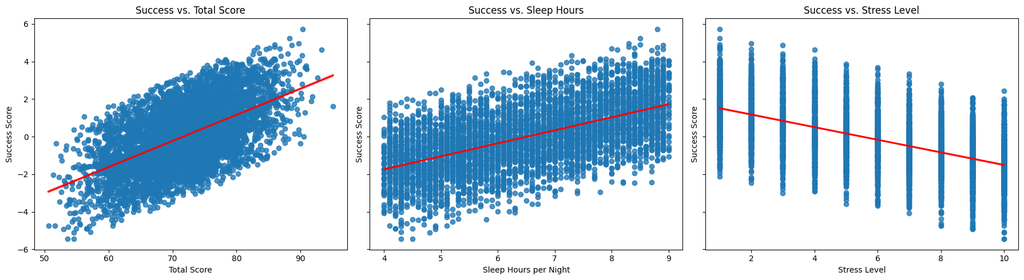

```python
fig, axes = plt.subplots(1, 3, figsize=(18, 5), sharey=True)

sns.regplot(
    x='Total_Score',
    y='Success_Score',
    data=df,
    ax=axes[0],
    line_kws={'color': 'red'}
)
axes[0].set_title('Success vs. Total Score')

sns.regplot(
    x='Sleep_Hours_per_Night',
    y='Success_Score',
    data=df,
    ax=axes[1],
    line_kws={'color': 'red'}
)
axes[1].set_title('Success vs. Sleep Hours')

sns.regplot(
    x='Stress_Level',
    y='Success_Score',
    data=df,
    ax=axes[2],
    line_kws={'color': 'red'}
)
axes[2].set_title('Success vs. Stress Level')

for ax in axes:
    ax.set_xlabel(ax.get_xlabel().replace('_', ' '))
    ax.set_ylabel('Success Score')

plt.tight_layout()
plt.show()
```

Now we can construct a preliminary regression model. We choose our Independent Y (Success_Score) and Dependent Set X (everything else) to analyze how much each feature contributes to our independent set. We will be fitting an **OLS (Ordinary Least Squares)** to determine the set of coefficients that minimizes our residuals. It essentially allows us to see how each predictor shifts the outcome.  
Whenever choosing to fit OLS, you want to inspect a few key features afterwards, specifically, **Linearity (are there residuals or is it fitted), The Spread of Residuals, Normality, and Colinearity.** We will create diagnosis plots for these and interrpret the results according.

Note that we technically we already checked colinearity at the beginning with a correlation matrix, however true Multicolinearity involves Variance Inflation Factors, which measures how much variance inflates when you regress it on other predictors.

**Show/Hide Code ▾**

```
                            OLS Regression Results
==============================================================================
Dep. Variable:          Success_Score   R-squared:                       0.341
Model:                            OLS   Adj. R-squared:                  0.339
Method:                 Least Squares   F-statistic:                     161.3
Date:                Sun, 06 Jul 2025   Prob (F-statistic):               0.00
Time:                        02:38:17   Log-Likelihood:                -8779.1
No. Observations:                5000   AIC:                         1.759e+04
Df Residuals:                    4983   BIC:                         1.770e+04
Df Model:                          16
Covariance Type:            nonrobust
============================================================================================================
                                               coef    std err          t      P>|t|      [0.025      0.975]
------------------------------------------------------------------------------------------------------------
Intercept                                   -9.8624      0.240    -41.141      0.000     -10.332      -9.392
C(Gender)[T.Male]                            0.0541      0.040      1.362      0.173      -0.024       0.132
C(Department)[T.CS]                         -0.0889      0.056     -1.583      0.114      -0.199       0.021
C(Department)[T.Engineering]                -0.0246      0.056     -0.440      0.660      -0.134       0.085
C(Department)[T.Mathematics]                -0.0254      0.056     -0.450      0.653      -0.136       0.085
C(Extracurricular_Activities)[T.Yes]         0.0096      0.040      0.242      0.809      -0.068       0.088
C(Internet_Access_at_Home)[T.Yes]           -0.0077      0.040     -0.194      0.846      -0.086       0.070
C(Parent_Education_Level)[T.High School]    -0.1413      0.058     -2.422      0.015      -0.256      -0.027
C(Parent_Education_Level)[T.Master's]       -0.0682      0.057     -1.190      0.234      -0.180       0.044
C(Parent_Education_Level)[T.PhD]            -0.0468      0.052     -0.893      0.372      -0.150       0.056
C(Family_Income_Level)[T.Low]               -0.0054      0.049     -0.111      0.912      -0.101       0.090
C(Family_Income_Level)[T.Medium]            -0.0542      0.049     -1.109      0.267      -0.150       0.042
Total_Score                                  0.1402      0.004     39.755      0.000       0.133       0.147
Participation_Score                         -0.0007      0.001     -0.920      0.358      -0.002       0.001
Attendance_Pct                            8.755e-05      0.001      0.063      0.949      -0.003       0.003
Study_Hours_per_Week                        -0.0015      0.003     -0.529      0.597      -0.007       0.004
Projects_Score                              -0.0007      0.002     -0.417      0.677      -0.004       0.003
==============================================================================
Omnibus:                      181.068   Durbin-Watson:                   2.034
Prob(Omnibus):                  0.000   Jarque-Bera (JB):               81.513
Skew:                           0.026   Prob(JB):                     1.99e-18
Kurtosis:                       2.377   Cond. No.                     1.69e+03
==============================================================================

Notes:
[1] Standard Errors assume that the covariance matrix of the errors is correctly specified.
[2] The condition number is large, 1.69e+03. This might indicate that there are
strong multicollinearity or other numerical problems.

Variance Inflation Factors
                                     variable         VIF
0                                  Intercept  145.982105
1                          C(Gender)[T.Male]    1.002944
2                        C(Department)[T.CS]    1.493855
3               C(Department)[T.Engineering]    1.501430
4               C(Department)[T.Mathematics]    1.493446
5       C(Extracurricular_Activities)[T.Yes]    1.005256
6          C(Internet_Access_at_Home)[T.Yes]    1.003407
7   C(Parent_Education_Level)[T.High School]    1.322680
8      C(Parent_Education_Level)[T.Master's]    1.333220
9           C(Parent_Education_Level)[T.PhD]    1.461838
10             C(Family_Income_Level)[T.Low]    1.348529
11          C(Family_Income_Level)[T.Medium]    1.349615
12                               Total_Score    1.652132
13                       Participation_Score    1.130898
14                            Attendance_Pct    1.003459
15                      Study_Hours_per_Week    1.001948
16                            Projects_Score    1.593587
```

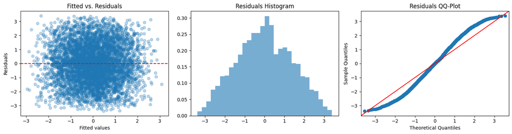

```python
dv  = 'Success_Score'
num = ['Total_Score', 'Participation_Score', 'Attendance_Pct',
       'Study_Hours_per_Week', 'Projects_Score']
cats = ['Gender','Department','Extracurricular_Activities','Internet_Access_at_Home','Parent_Education_Level', 'Family_Income_Level']

formula = (dv + ' ~ ' + ' + '.join(num) + ' + ' + ' + '.join(f'C({c})' for c in cats))
model = ols(formula, data=df).fit()
print(model.summary())

def diagnostic_plots(model):
    exog          = model.model.exog
    exog_names    = model.model.exog_names
    vif_data = pd.DataFrame({
        "variable": exog_names,
        "VIF": [
            variance_inflation_factor(exog, i)
            for i in range(exog.shape[1])
        ]
    })
    print("\nVariance Inflation Factors\n", vif_data, "\n")

    fitted = model.fittedvalues
    resid  = model.resid

    fig, (ax1, ax2, ax3) = plt.subplots(1,3, figsize=(15,4))
    ax1.scatter(fitted, resid, alpha=0.3)
    ax1.axhline(0, color='red', linestyle='--')
    ax1.set_title('Fitted vs. Residuals')
    ax1.set_xlabel('Fitted values')
    ax1.set_ylabel('Residuals')

    ax2.hist(resid, bins=30, density=True, alpha=0.6)
    ax2.set_title('Residuals Histogram')

    sm.qqplot(resid, line='45', ax=ax3)
    ax3.set_title('Residuals QQ-Plot')

    plt.tight_layout()
    plt.show()

diagnostic_plots(model)
```

## **Model Summary and Conclusions**

From our **OLS** application, we can see that our R² value is 0.341, meaning that our predictors explain 34% of the variance in Success_Score. And our F-Statistic: 161.3 with a probability < 0.01, show that **our predictors are highly significant in explaining the Success_Score.**  
As for key coefficients, our Total_Score coefficient of 0.14 is highly significant! It indicates that **every one-point rise in total academic score → +0.14 on Success_Score**. Additionally, our Parent_Education_Level also has a modest impact, as **students whose parents only completed high school, on average have a composite Success_Score that is 0.14 standard deviations lower than a student whose parents have higher education.**

# **Recap of Everything So Far!**

Before we move further, lets quickly go over everything we've already done to understand our data.

## **Data Preprocessing**

We imported various libraries such as pandas, numpy, matplot, seaborn, spicy.stats, statsmodels, and sklearn.

We began parsing through turning raw text columns into native types, renamed “Attendance (%)” to Attendance_Pct and “Stress_Level (1-10)” to Stress_Level, created miss_PE and Part_High as integer/boolean flags, binned participation into quartiles and later into a high/low Boolean for single-imputation and dropped ID, name, and email columns

We also organized our data by cleaning the DataFrame, z-scoring three Success inputs, dropping extras, and creating a single Success_Score.

## **Basic Data Exploration & Summary Statistics**

We utilized various Statistical Methods for:

Missing-data analysis (t-tests + χ²) and visualization using heatmap & barplots for our Hypothesis test that Parent_Edu is MAR.

Correlation analysis (Pearson matrix + pairplot) and visualization with a scatter matrix for identifying top numeric predictors.

Categorical analysis (ANOVA + boxplots) and visualization with a multiway ANOVA table & boxplots for finding the categorical driver.

Simple regressions (regplots) + three red line scatterplots to determine our strongest linear predictor.

Full OLS model and diagnostics plus a summary table, VIFs, residual plots allowed for R²/R²adj, coefficient interpretations, and collinearity check.

We reached many conclusions, a few of which being:

Participation_Score significantly predicts missing Parent_Education Level (p≈0.008), therefore it is Missing At Random (MAR).

OLS: every point in Total_Score adds ~0.14 to Success_Score, and having only High School educated parents knocks you down ~0.14 (all else equal).

ANOVA shows no significant categorical effects on Success_Score (all p>0.05).

# **Primary Analysis & Visualization**

Now that we have finished exploring our data, it is time to being our primary analysis! Before we begin applying models to our data, the first thing we need to is form a hypothesis.

Based on our findings, we can assume the best model for our dataset would be Random Forest. Random Forest is a Machine Learning Model that is typically used when we have multiple categorical and numeric features. However, our previous conclusion showed us our categorical features are irrelevant to our analysis, therefore we are only going to be using our numerical features to train and test our model. We still believe Random Forest will be the best because its robust to overfitting and helps us capture nonlinear relationships and more complex patterns. It still typically has the best performance compared to other models when working on real datasests that have been cleaned out and only contain numerical features.

To test our hypothesis, we will be comparing Random Forest with other models that both tend to perform well on numerical data and are common models we have gone over in class. For this comparison, we will be using Decision Tree and Support Vector Regression

Models such as K-nearest neigbor and K-means clustering would not work due to them being unsupervised machine learning models. Because our data is already labeled, we will be using superivised learning algorithms to predict the success score of new students.

Note: we included Support Vector Regression (SVR) in the dictionary which was not covered much in the material since its good for predicting continuos variables and might work well with our data.

[Learn more about Random Forest here!](https://www.geeksforgeeks.org/machine-learning/random-forest-algorithm-in-machine-learning/)

**Show/Hide Code ▾**

```python
models = \
          {
    'SVR': SVR(kernel='rbf', C=1.0, epsilon=0.1),
    'DecisionTree': DecisionTreeRegressor(),
    'RandomForest': RandomForestRegressor()

          }
```

Before we begin appling models to our data, we need to scale and split our data before training. This ensures effective results in two ways: 1) scaled data allows for more consistent results across our models and 2) splitting data ensures that we can measure performance data that was not involved in training, for a more accurate assessment. Here we can quickly scale and split our data using the sklearn library's StandardScaler() and train_test_split() functions.

[Learn more about train_test_split here!](https://scikit-learn.org/stable/modules/generated/sklearn.model_selection.train_test_split.html)

**Show/Hide Code ▾**

```python
test_size = 0.2
seed = 42

X = df[['Total_Score', 'Midterm_Score', 'Final_Score', 'Assignments_Avg', 'Quizzes_Avg',
'Participation_Score', 'Stress_Level', 'Attendance_Pct', 'Study_Hours_per_Week', 'Projects_Score', 'Sleep_Hours_per_Night']]
Y = df['Success_Score']

scaler = StandardScaler()

X_train, X_test, y_train, y_test = train_test_split(X, Y, test_size=test_size, random_state=seed)
X_train_scaled = scaler.fit_transform(X_train)
X_test_scaled = scaler.fit_transform(X_test)
```

Now that we have split our data, we want to introduce folds. This is essentially a cross validation technique where we split our data into distinct folds, fit the model on each train fold, evaluate it on a corresponding test fold, and receive a metric of the cross-validated accuracy. This encourages stability, fair comparison and helps prevent overfitting on our model. It is essential for comparing multiple models in a reproducible and unbiased manner!

[Learn more about k-fold here!](https://www.geeksforgeeks.org/machine-learning/k-fold-cross-validation-in-machine-learning/)

**Show/Hide Code ▾**

```python
kfolds = 5

kf = KFold(n_splits=kfolds, shuffle=True, random_state=seed)
for model_name, model in models.items():
  np.random.seed(42)
  cv = kf
  scoring = 'r2'
  print(f"Model: {model_name}")

  cv_scores = cross_val_score(model, X_train_scaled, y_train, cv=cv, scoring=scoring, error_score='raise')

  print(f"Cross-validated Accuracy: {cv_scores.mean()} (+/- {cv_scores.std()}) \n")
```

```
Model: SVR
Cross-validated Accuracy: 0.9944765863479545 (+/- 0.0005274473491221804)

Model: DecisionTree
Cross-validated Accuracy: 0.9630752109050824 (+/- 0.002358540757590973)

Model: RandomForest
Cross-validated Accuracy: 0.9908235949762073 (+/- 0.0007330670255108539)
```

Now that we have our cross-validation accuracy, we can see that our coefficident of determination is extremely close to 1, with the highest accuracy being SVR at 99.4% accurate!

## **Visualization**

Since we have completed our k folds and determined accuracy, we want to visualize our models against a regression line to show the predictions against true values. We already have R² for accuracy, but we also want a metric for error. We will be using Mean Squared Error, a measure that evaluates the performance of a model in regression tasks by assessing the average squared differene between predicted and actual values

[Learn more about Mean Squared Error here!](https://www.geeksforgeeks.org/maths/mean-squared-error/)

**Show/Hide Code ▾**

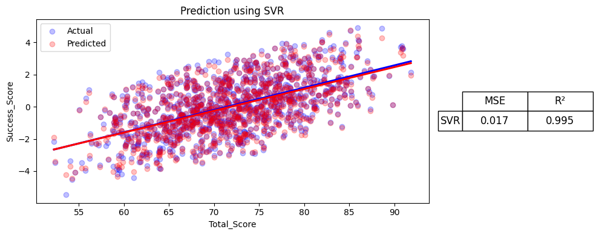

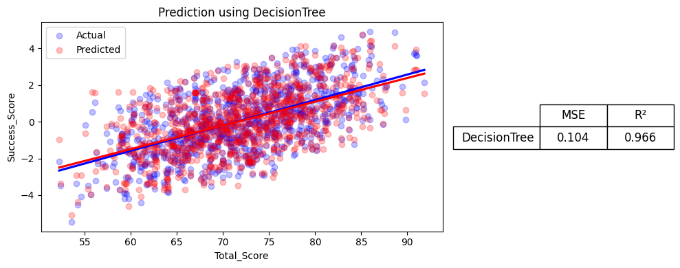

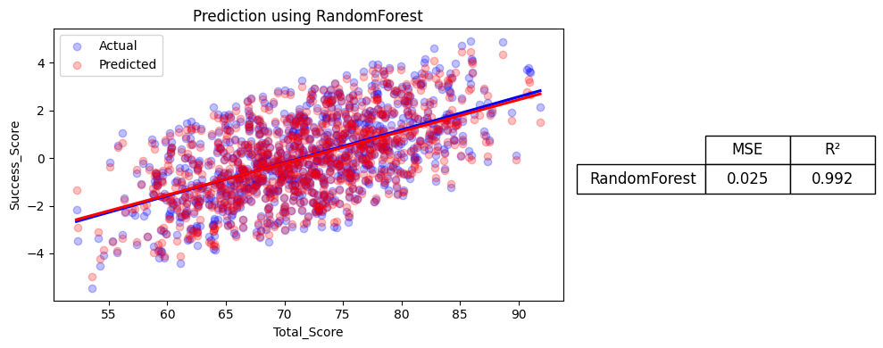

```python
for name, model in models.items():
    model.fit(X_train_scaled, y_train)
    y_pred = model.predict(X_test_scaled)
    mse = mean_squared_error(y_test, y_pred)
    r2 = r2_score(y_test, y_pred)

    fig, (ax_plot, ax_table) = plt.subplots(ncols=2, figsize=(10, 4), gridspec_kw={"width_ratios": [3, 1]})
    sns.regplot(x=X_test["Total_Score"], y=y_test,    ax=ax_plot, color="blue",  label="Actual",    scatter_kws={"alpha": 0.25}, ci=None)
    sns.regplot(x=X_test["Total_Score"], y=y_pred,    ax=ax_plot, color="red",   label="Predicted", scatter_kws={"alpha": 0.25}, ci=None)

    ax_plot.set_title(f"Prediction using {name}")
    ax_plot.set_ylabel("Success_Score")
    ax_plot.legend()

    ax_table.axis("off")
    table_data = [[f"{mse:.3f}", f"{r2:.3f}"]]
    tbl = ax_table.table(
        cellText=table_data,
        colLabels=["MSE", "R²"],
        rowLabels=[name],
        cellLoc="center",
        loc="center"
    )
    tbl.auto_set_font_size(False)
    tbl.set_fontsize(12)
    tbl.scale(1, 2)

    plt.tight_layout()
    plt.show()
```

Additionally, we've included the first 5 predictions of each model, just so we can actually see what's being produced!

**Show/Hide Code ▾**

```python
for name, model in models.items():
    y_pred = model.predict(X_test_scaled)

    df_preds = pd.DataFrame({
        "Total_Score": X_test["Total_Score"].values,
        "Actual": y_test,
        "Predicted": y_pred
    }, index=X_test.index)
    print(f"\nFirst 5 predictions for {name}:")
    display(df_preds.head(5))
```

```
First 5 predictions for SVR:
```

|  | Total_Score | Actual | Predicted |
| --- | --- | --- | --- |
| 1501 | 67.8110 | -0.987970 | -1.003164 |
| 2586 | 74.6450 | 2.794757 | 2.791958 |
| 2653 | 74.8580 | 0.403091 | 0.357520 |
| 1055 | 72.8965 | -0.563174 | -0.670651 |
| 705 | 58.2260 | -2.242625 | -1.851079 |

```
First 5 predictions for DecisionTree:
```

|  | Total_Score | Actual | Predicted |
| --- | --- | --- | --- |
| 1501 | 67.8110 | -0.987970 | -1.282921 |
| 2586 | 74.6450 | 2.794757 | 2.864432 |
| 2653 | 74.8580 | 0.403091 | 0.701639 |
| 1055 | 72.8965 | -0.563174 | -0.621257 |
| 705 | 58.2260 | -2.242625 | -1.946375 |

```
First 5 predictions for RandomForest:
```

|  | Total_Score | Actual | Predicted |
| --- | --- | --- | --- |
| 1501 | 67.8110 | -0.987970 | -0.854614 |
| 2586 | 74.6450 | 2.794757 | 2.939577 |
| 2653 | 74.8580 | 0.403091 | 0.554949 |
| 1055 | 72.8965 | -0.563174 | -0.627612 |
| 705 | 58.2260 | -2.242625 | -1.946760 |

Finally, we want to compare all of our models to a Linear Regression Model. We want to do this because our model is entirely based on regression features, and our dependent variable is constructed based on those features. Based on this logic, a Linear Regression model should hold perfect accuracy, making it a good metric to compare against for our other models!

[Learn more about Linear Regression in Machine Learning here!](https://www.geeksforgeeks.org/machine-learning/ml-linear-regression/)

**Show/Hide Code ▾**

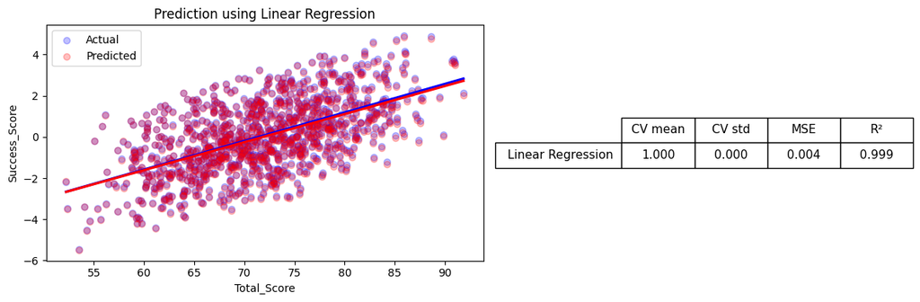

```python
name = "Linear Regression"
cv_scores = cross_val_score(LinearRegression(), X_train_scaled, y_train, cv=kf, scoring="r2", error_score="raise")
cv_mean, cv_std = cv_scores.mean(), cv_scores.std()

model = LinearRegression().fit(X_train_scaled, y_train)
y_pred = model.predict(X_test_scaled)
mse = mean_squared_error(y_test, y_pred)
r2 = r2_score(y_test, y_pred)

fig,(ax_plot,ax_table)=plt.subplots(
    ncols=2,
    figsize=(12,4),
    gridspec_kw={"width_ratios":[3,2]}
)
sns.regplot(x=X_test["Total_Score"],y=y_test, ax=ax_plot,    color="blue",  label="Actual",    scatter_kws={"alpha":0.25}, ci=None)
sns.regplot(x=X_test["Total_Score"],y=y_pred, ax=ax_plot,    color="red",   label="Predicted", scatter_kws={"alpha":0.25}, ci=None)
ax_plot.set_title(f"Prediction using {name}"); ax_plot.set_ylabel("Success_Score"); ax_plot.legend()

ax_table.axis("off")
tbl = ax_table.table(
    cellText=[[f"{cv_mean:.3f}", f"{cv_std:.3f}", f"{mse:.3f}", f"{r2:.3f}"]],
    colLabels=["CV mean","CV std","MSE","R²"],
    rowLabels=[name],
    cellLoc="center",
    loc="center",
    colWidths=[0.25,0.25,0.25,0.25]
)
tbl.auto_set_font_size(False); tbl.set_fontsize(11); tbl.scale(1,2)
plt.tight_layout(); plt.show()
```

And we have also included the first 5 predictions below for your viewing pleasure :)

**Show/Hide Code ▾**

```python
preds_df = pd.DataFrame({

    "Total_Score": X_test["Total_Score"].values,
    "Actual": y_test,
    "Predicted": y_pred
}, index=X_test.index).round(3)
print(f"\nFirst 5 predictions for Linear Regression:")
display(preds_df.head(5))
```

```
First 5 predictions for Linear Regression:
```

|  | Total_Score | Actual | Predicted |
| --- | --- | --- | --- |
| 1501 | 67.811 | -0.988 | -1.034 |
| 2586 | 74.645 | 2.795 | 2.750 |
| 2653 | 74.858 | 0.403 | 0.358 |
| 1055 | 72.896 | -0.563 | -0.642 |
| 705 | 58.226 | -2.243 | -2.233 |

# **Insights & Conclusions**

Finally, it is time to begin reviewing all of our analysis and discuss our conclusions!

However, after training and evaluating all models, our results tell a different story. Surprisingly, Random Forest did not outperform the other two algorithms. While it performed well and showed high predictive capability, it was ultimately outclassed by both Support Vector Regression and Linear Regression. The Random Forest model retained strong accuracy, but it fell short in terms of minimizing prediction error (MSE), due to a higher value, and explaining the variance in our data (R²), due to underperforming against SVR.

In real world practice, our model can be applied by schools, advisors, or academic support services to identify students who will perform less successfully. Schools may input current data, such as total academic score, reported sleeping habits, and stress levels into our model in order to make predictions about which students will perform well and which students will require special intervention or not. This can help the professor, counselor, and school better understand what the student needs in order to improve their chances of being successful.

[For more information regarding the relationship of academic stress and student wellbeing, click here!](https://www.nature.com/articles/s41599-025-04698-y)

[For interest in other studies exploring factors shaping academic success, click here!](https://pmc.ncbi.nlm.nih.gov/articles/PMC10875422/)

[For a study considering success factors from a student based perspective, click here!](https://www.researchgate.net/publication/349223588_Success_factors_at_university_from_students'_perspective)